# Data Visualization

Brian Linn

December 14, 2017

## A Quick Introduction to base R graphics

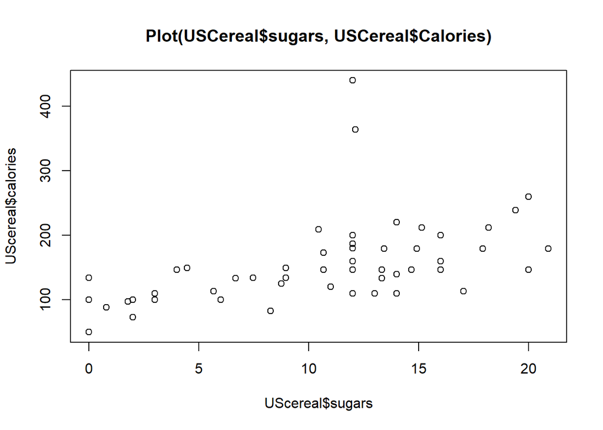

```r
library(MASS)
plot(UScereal$sugars, UScereal$calories)
title("Plot(USCereal$sugars, USCereal$Calories)")
```

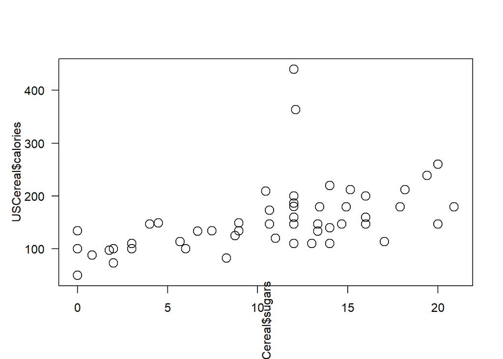

```r
#primarily used by other packages
#Get the data and load the grid package
library(MASS)
x <- UScereal$sugars
y <- UScereal$calories
library(grid)

#Grid code to generate the plot
pushViewport(plotViewport())
pushViewport(dataViewport(x, y))
grid.rect()
grid.xaxis()
grid.yaxis()
grid.points(x, y)
grid.text("USCereal$calories", x = unit(-3, "lines"), rot = 90)
grid.text("USCereal$sugars", y = unit(-3, "lines"), rot = 90)
popViewport(2)
```

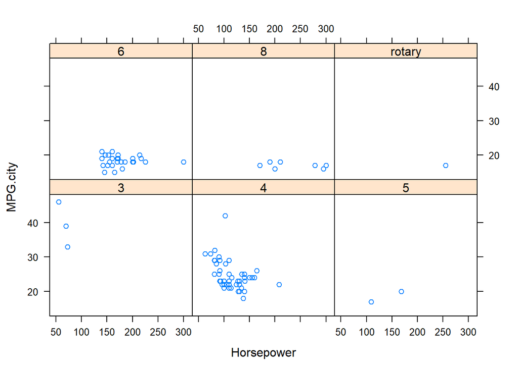

```r
library(MASS)
library(lattice)
xyplot(MPG.city ~ Horsepower | Cylinders, data = Cars93)
```

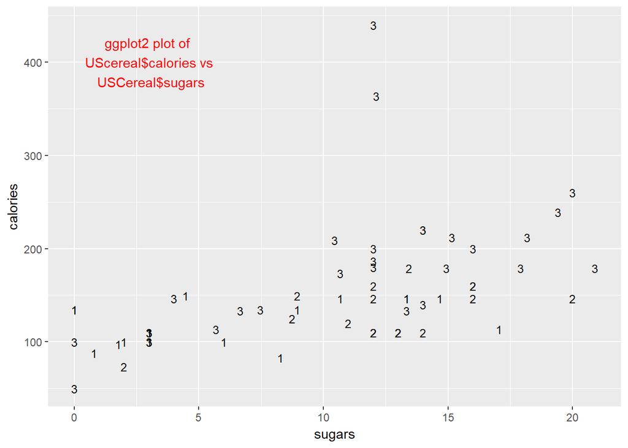

```r
library(MASS)
library(ggplot2)
title <- "ggplot2 plot of \n UScereal$calories vs \n USCereal$sugars"
baseplot <- ggplot(UScereal, aes(x = sugars, y = calories))
baseplot +
        geom_point(shape = as.character(UScereal$shelf), size = 3) +
        annotate("text", label = title, x = 3, y = 400,
                 colour = "red")
```

### Creating an exploratory plot array

In this exercise, you’ll construct a simple exploratory plot from a data frame that gives values for three variables, recorded over two winter heating seasons. The variables are:

Temp: a measure of the outside temperature during one week Gas: the amount of heating gas consumed during that week Insul: a categorical variable with two values, indicating whether the measurements were made before or after an insulation upgrade was made to the house

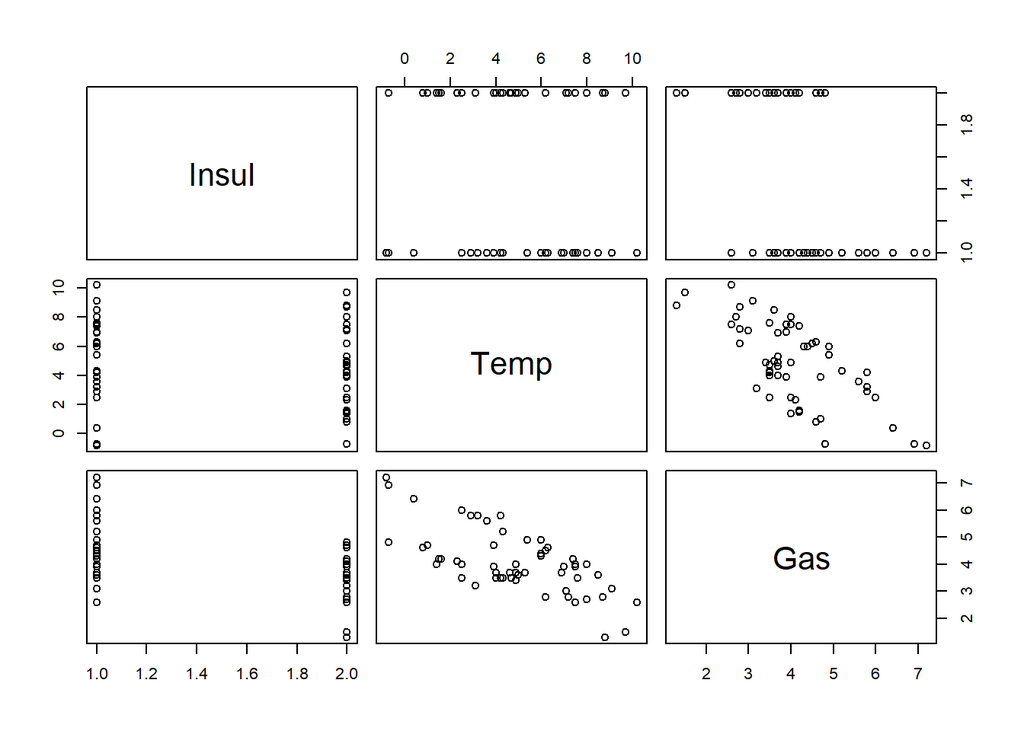

```r
library(MASS)
plot(whiteside)
```

### Creating an explanatory scatterplot

In constrast to the exploratory analysis plot you created in the previous exercise, this exercise asks you to create a simple explanatory scatterplot, suitable for sharing with others.

Here, it is important to make editorial choices in constructing this plot, rather than depending entirely on default options. In particular, the important editorial aspects of this plot are: first, the variables to be plotted, and second, the axis labels, which are specified as strings to the xlab and ylab arguments to the plot() function.

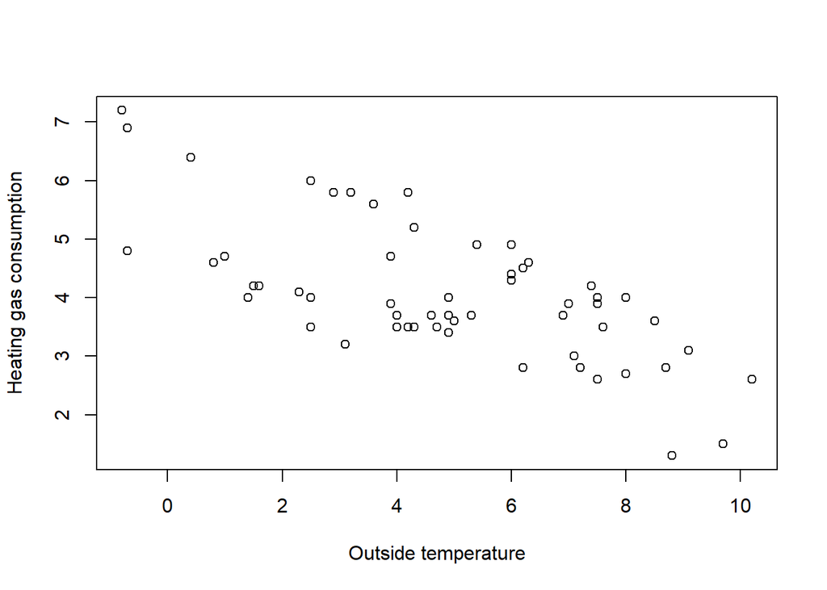

```r
plot(whiteside$Temp, whiteside$Gas,
     xlab = "Outside temperature",
     ylab = "Heating gas consumption")
```

### The plot() function is generic

One of the key features of the plot() function is that it is generic, meaning that the results of applying the function depend on the nature of the object to which it is applied.

In the first exercise of this chapter, applying the plot() function to the whiteside data frame resulted in a plot array. Here, we obtain a fundamentally different kind of result when we apply the same function to Insul, a factor variable from the same data frame.

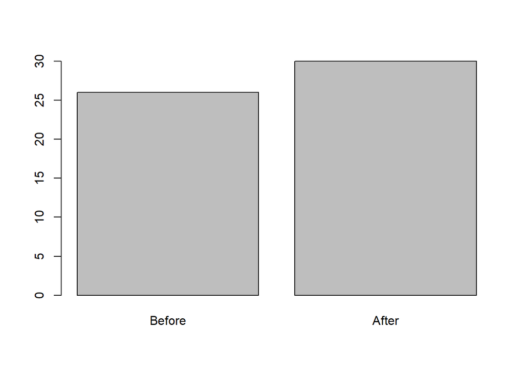

```r
plot(whiteside$Insul)
```

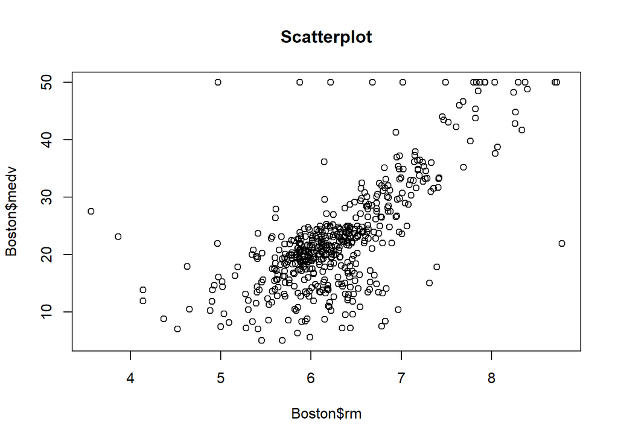

```r
library(MASS)
plot(Boston$rm, Boston$medv, main = "Scatterplot")
```

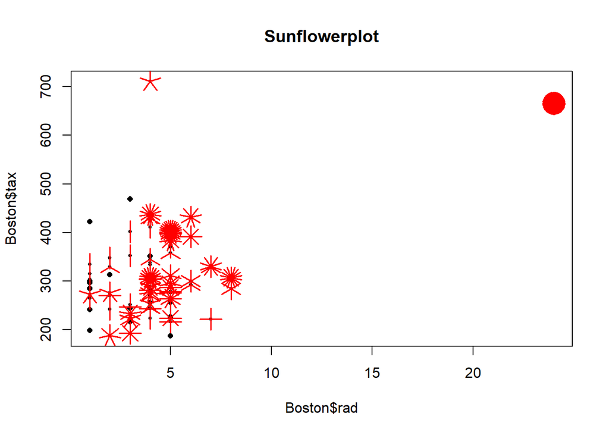

```r
library(MASS)
sunflowerplot(Boston$rad, Boston$tax, main = "Sunflowerplot")
```

```r
#The sunflower plot shows another petal for each repeated value - which is missing form the scatterplot
```

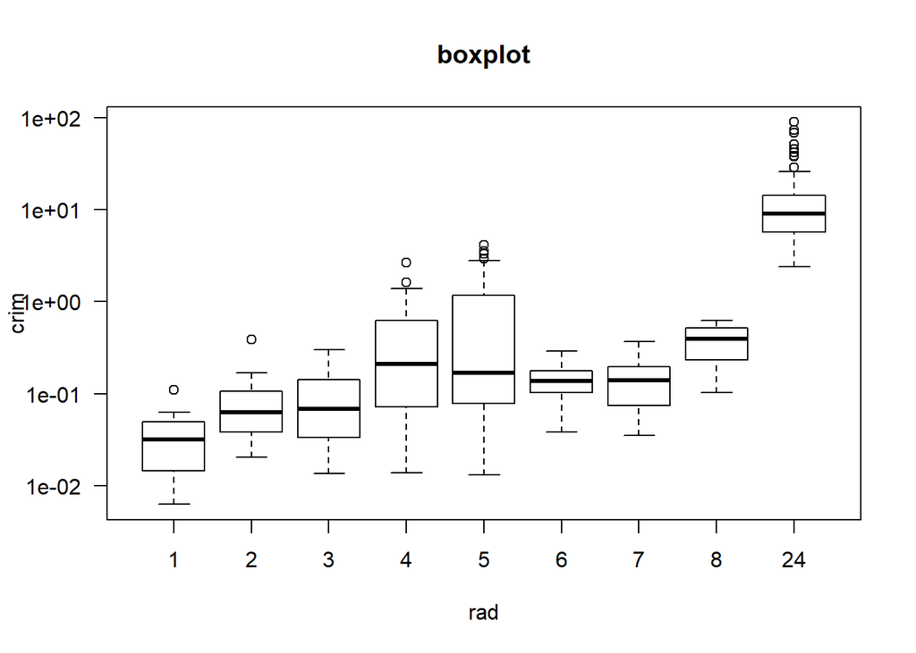

```r
library(MASS)
boxplot(crim ~ rad, data = Boston, log = "y", las = 1,
        main = "boxplot", xlab = "rad", ylab = "crim")
```

[figure not shown]

```r
mosaicplot(cyl ~ gear, data = mtcars, main = "Mosaicplot")
```

```r
#shows relationship between two categorical variables or enumerated numerical values
```

### Adding details to a plot using point shapes, color, and reference lines

Adding additional details to your explanatory plots can help emphasize certain aspects of your data. For example, by specifying the pch and col arguments to the plot() function, you can add different point shapes and colors to show how different variables or subsets of your data relate to each other. In addition, you can add a new set of points to your existing scatterplot with the points() function, and add reference lines with the abline() function.

This exercise asks you to use these methods to create an enhanced scatterplot that effectively shows how three variables in the Cars93 data frame relate to each other. These variables are:

Price: the average sale price for a car Max.Price: the highest recorded price for that car Min.Price: the lowest recorded price for that car

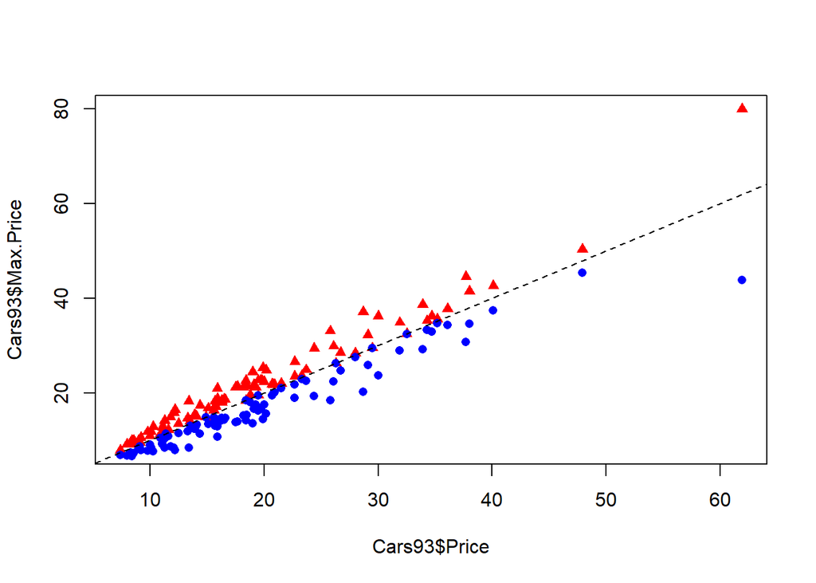

```r
# Load the MASS package
library(MASS)

# Plot Max.Price vs. Price as red triangles
plot(Cars93$Price, Cars93$Max.Price,
     pch = 17,
     col = "red")

# Add Min.Price vs. Price as blue circles
points(Cars93$Price, Cars93$Min.Price,
       pch = 16,
       col = "blue")

# Add an equality reference line with abline()
abline(a = 0, b = 1, lty = 2)
```

### Creating multiple plot arrays

You can plot multiple graphs on a single pane using the par() function with its mfrow parameter. For example, par(mfrow = c(1, 2)) creates a plot array with 1 row and 2 columns, allowing you to view two graphs side-by-side. This way, you can compare and contrast different datasets or different views of the same dataset. This exercise asks you to compare two views of the Animals2 dataset from the robustbase package, differing in how its variables are represented.

The objective of this exercise is to emphasize that the original representation of the variables that we have in a dataset is not always the best one for visualization or analysis. By representing the original variables in log scale, for example, we can better see and understand the data.

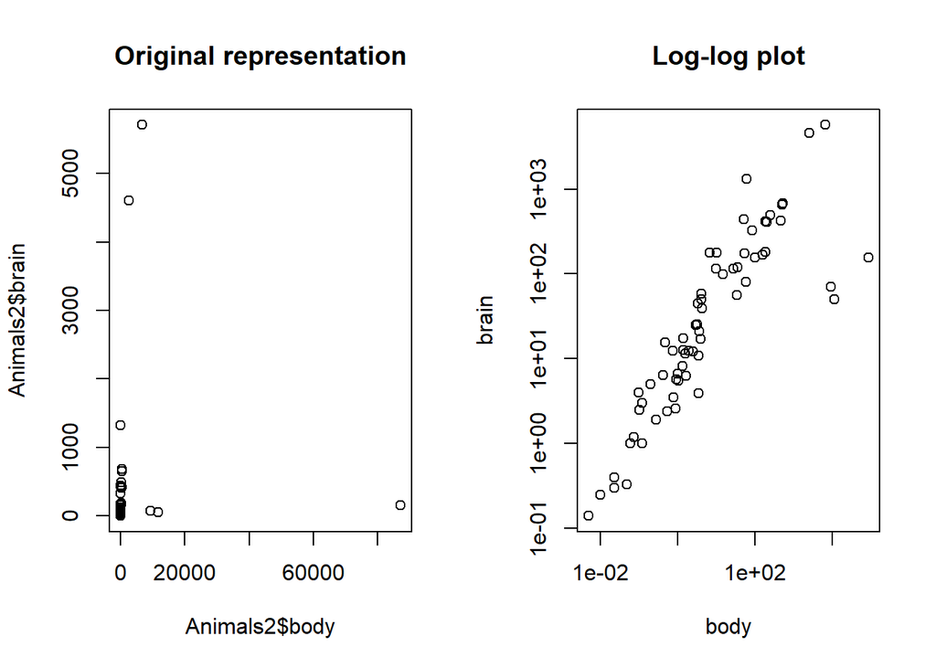

```r
# Load the robustbase package
library(robustbase)

# Set up the side-by-side plot array
par(mfrow = c(1, 2))

# First plot: brain vs. body in its original form
plot(Animals2$body, Animals2$brain)

# Add the first title
title(main = "Original representation")

# Second plot: log-log plot of brain vs. body
plot(Animals2, log = "xy")

# Add the second title
title(main = "Log-log plot")
```

### Avoid pie charts

The same dataset can be displayed or summarized in many different ways, but some are much more suitable than others.

Despite their general popularity, pie charts are often a poor choice. Though R allows pie charts with the pie() function, even the help file for this function argues against their use. Specifically, the help file includes a “Note” that begins with the words: “Pie charts are a very bad way of displaying information.”

Bar charts are a recommended alternative and, in this exercise, you’ll see why.

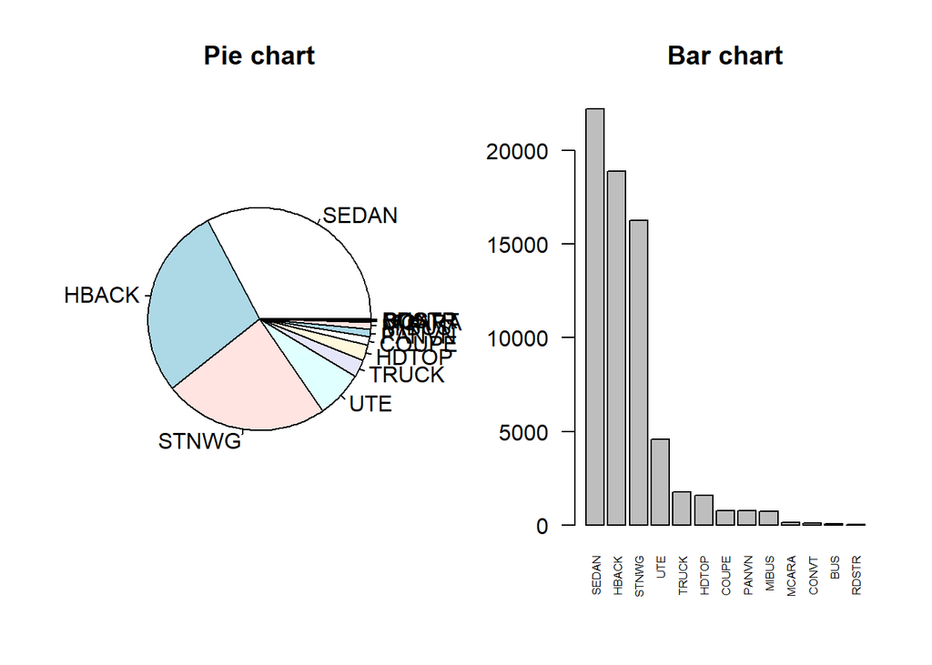

```r
# Load the insuranceData package
library(insuranceData)

# Use the data() function to get the dataCar data frame
data("dataCar")

# Set up a side-by-side plot array
par(mfrow = c(1, 2))

# Create a table of veh_body record counts and sort
tbl <- sort(table(dataCar$veh_body),
            decreasing = TRUE)

# Create the pie chart and give it a title
pie(tbl)
title(main = "Pie chart")

# Create the barplot with perpendicular, half-sized labels
barplot(tbl, las = 2, cex.names = 0.5)
title(main = "Bar chart")
```

```r
#las to control the direction of the labels
#cex.names to control the size of the labels - makes them half size
```

## Different Plot Types

### Characterizing a Single Variable

What do we expect to see? For numerical values we expect the distribution to follow the gaussian curve - normal distribution - the bell curve -histograms, density plots, normal qq-plot

The hist() and truehist() functions

Histograms are probably the best-known way of looking at how the values of a numerical variable are distributed over their range, and R provides several different histogram implementations.

The purpose of this exercise is to introduce two of these:

hist() is part of base R and its default option yields a histogram based on the number of times a record falls into each of the bins on which the histogram is based. truehist() is from the MASS package and scales these counts to give an estimate of the probability density.

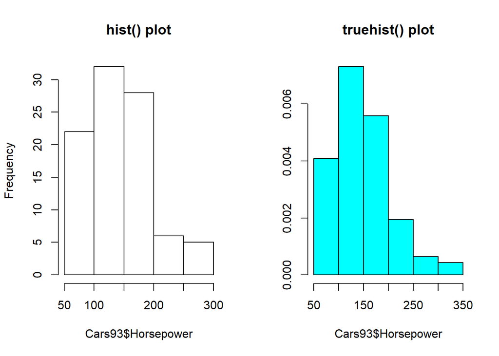

```r
# Set up a side-by-side plot array
par(mfrow = c(1, 2))

# Create a histogram of counts with hist()
hist(Cars93$Horsepower,
     main = "hist() plot")

# Create a normalized histogram with truehist()
truehist(Cars93$Horsepower,
         main = "truehist() plot")
```

### Density plots as smoothed histograms

While they are probably not as well known as the histogram, density estimates may be regarded as smoothed histograms, designed to give a better estimate of the density function for a random variable.

In this exercise, you’ll use the ChickWeight dataset, which contains a collection of chicks’ weights. You will first select for the chicks that are 16 weeks old. Then, you’ll create a histogram using the truehist() function, and add its density plot on top, using the lines() and density() functions with their default options. The density plot of this type of variable is often expected to conform approximately to the bell-shaped curve, otherwise known as the Gaussian distribution. Let’s find out whether that’s the case for this dataset. Create the variable index16 using the which() function that selects records from the ChickWeight data frame with Time equal to 16. Create the variable weights that gives the weights of the 16-week old chicks. Use the truehist() function to generate a histogram from weights. Use the lines() and density() functions to overlay a density plot of the weights values on the histogram.

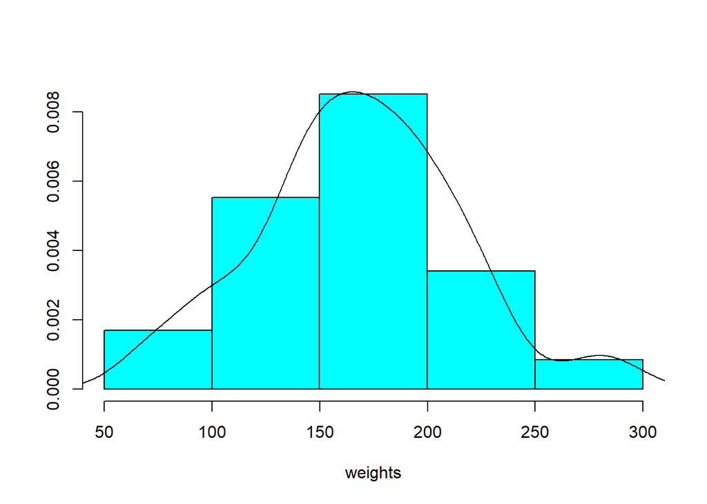

```r
par(mfrow = c(1,1))
# Create index16, pointing to 16-week chicks
index16 <- which(ChickWeight$Time == 16)

# Get the 16-week chick weights
weights <- ChickWeight$weight[index16]

# Plot the normalized histogram
truehist(weights)

# Add the density curve to the histogram
lines(density(weights))
```

### Using the qqPlot() function to see many details in data

A practical limitation of both histograms and density estimates is that, if we want to know whether the Gaussian distribution assumption is reasonable for our data, it is difficult to tell.

The quantile-quantile plot, or QQ-plot, is a useful alternative: we sort our data, plot it against a specially-designed x-axis based on our reference distribution (e.g., the Gaussian “bell curve”), and look to see whether the points lie approximately on a straight line. In R, several QQ-plot implementations are available, but the most convenient one is the qqPlot() function in the car package.

The first part of this exercise applies this function to the 16-week chick weight data considered in the last exercise, to show that the Gaussian distribution appears to be reasonable here. The second part of the exercise applies this function to another variable where the Gaussian distribution is obviously a poor fit, but the results also show the presence of repeated values (flat stretches in the plot) and portions of the data range where there are no observations (vertical “jumps” in the plot).

Load the car package to make the qqPlot() function available for use. Create the variable index16 using the which() function that selects records from the ChickWeight data frame with Time equal to 16. Create the variable weights that gives the weights of the 16-week old chicks. Apply the qqPlot() function to the weights data, noting that almost all of the points fall within the confidence intervals around the reference line, indicating a reasonable conformance with the Gaussian distribution for this data sequence. Apply the qqPlot() function to the tax variable from the Boston data frame in the MASS package.

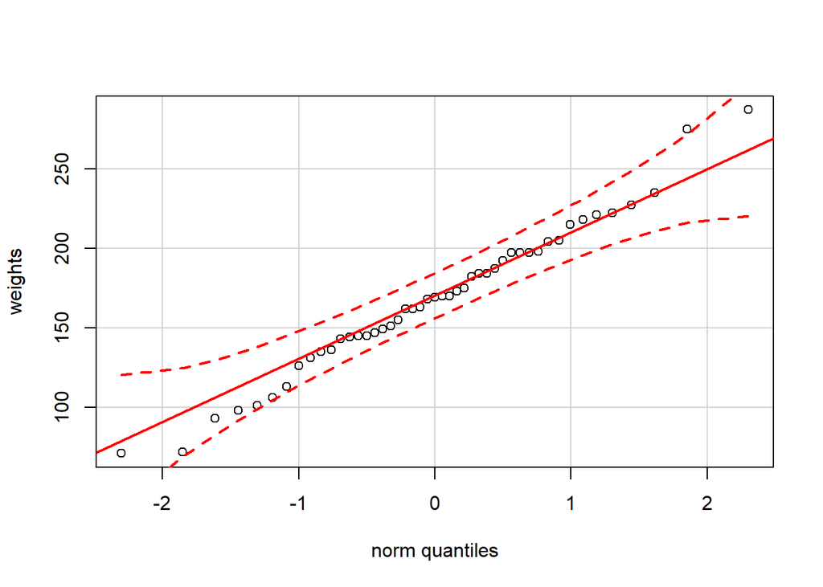

```r
# Load the car package to make qqPlot() available
library(car)

# Create index16, pointing to 16-week chicks
index16 <- which(ChickWeight$Time == 16)

# Get the 16-week chick weights
weights <- ChickWeight$weight[index16]

# Show the normal QQ-plot of the chick weights
qqPlot(weights)
```

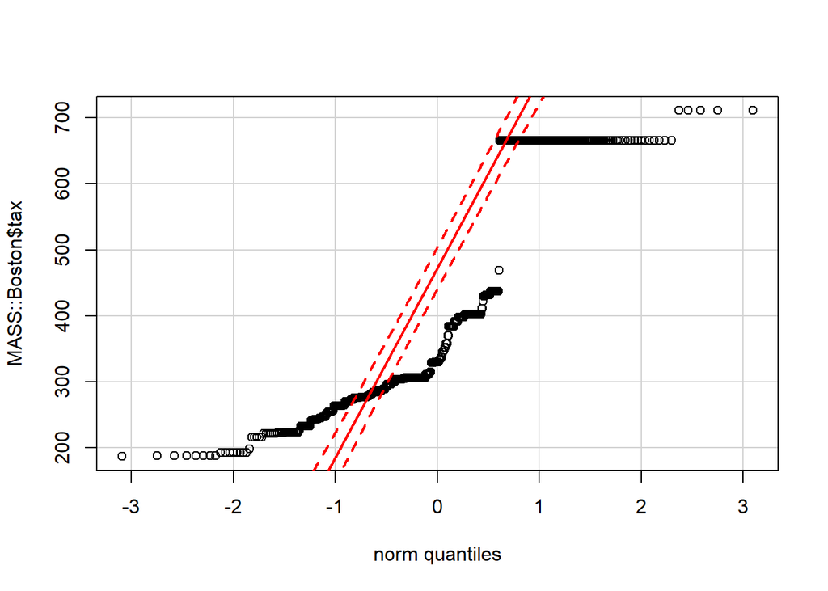

```r
# Show the normal QQ-plot of the Boston$tax data
qqPlot(MASS::Boston$tax)
```

### Visualizing Relations Between Two Variables

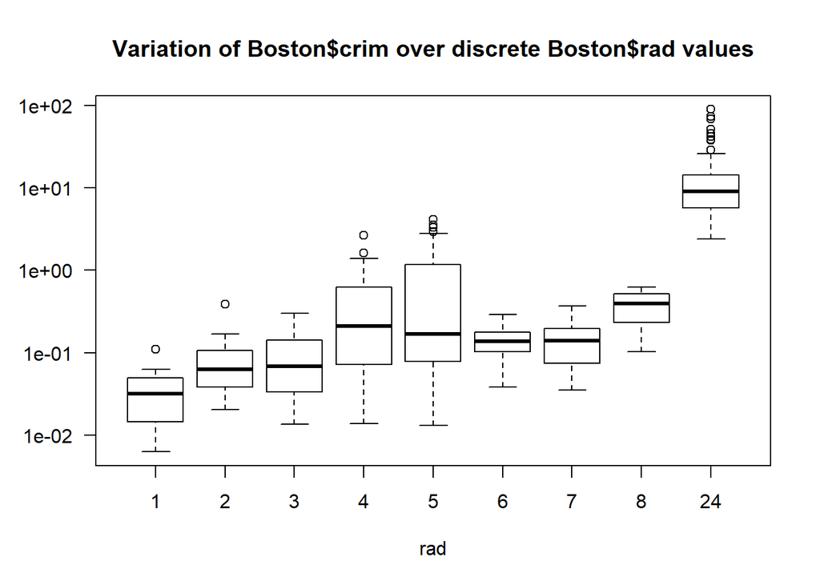

```r
library(MASS)
boxplot(crim ~ rad, data = Boston, log = "y", las = 1, xlab = "rad")
title("Variation of Boston$crim over discrete Boston$rad values")
```

### The sunflowerplot() function for repeated numerical data

A scatterplot represents each (x, y) pair in a dataset by a single point. If some of these pairs are repeated (i.e. if the same combination of x and y values appears more than once and thus lie on top of each other), we can’t see this in a scatterplot. Several approaches have been developed to deal with this problem, including jittering, which adds small random values to each x and y value, so repeated points will appear as clusters of nearby points.

A useful alternative that is equally effective in representing repeated data points is the sunflowerplot, which represents each repeated point by a “sunflower,” with one “petal” for each repetition of a data point.

This exercise asks you to construct both a scatterplot and a sunflowerplot from the same dataset, one that contains repeated data points. Comparing these plots allows you to see how much information can be lost in a standard scatterplot when some data points appear many times. Use the par() function to set the mfrow parameter for a side-by-side plot array. For the left-hand plot, use the plot() function to construct a scatterplot of the rad variable versus the zn variable, both from the Boston data frame in the MASS package. Use the title() function to add the title “Standard scatterplot” to this plot. For the right-hand plot, apply the sunflowerplot() function to the same data to see the presence of repeated data points, not evident from the scatterplot on the left. Use the title() function to add the title “Sunflower plot”.

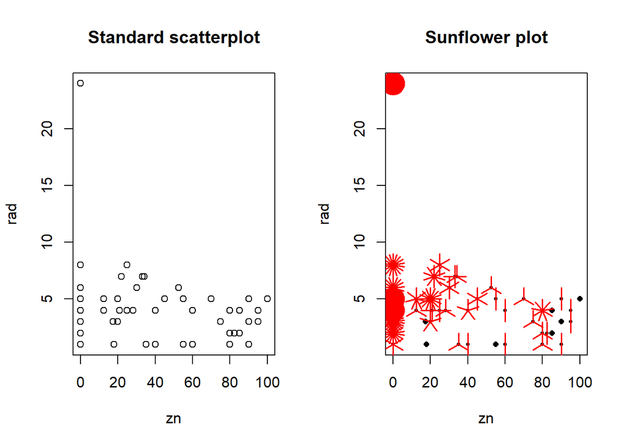

```r
mfrow <- function(rows, cols){
        par(mfrow = c(rows, cols))
}
# Set up a side-by-side plot array
mfrow(1, 2)
#par(mfrow = c(1, 2))

# Create the standard scatterplot
plot(rad ~ zn, data = Boston)

# Add the title
title(main = "Standard scatterplot")

# Create the sunflowerplot
sunflowerplot(rad ~ zn, data = Boston)

# Add the title
title(main = "Sunflower plot")
```

```r
#viewer(1,1)
```

### Useful options for the boxplot() function

The boxplot() function shows how the distribution of a numerical variable y differs across the unique levels of a second variable, x. To be effective, this second variable should not have too many unique levels (e.g., 10 or fewer is good; many more than this makes the plot difficult to interpret).

The boxplot() function also has a number of optional parameters and this exercise asks you to use three of them to obtain a more informative plot:

varwidth allows for variable-width boxplots that show the different sizes of the data subsets. log allows for log-transformed y-values. las allows for more readable axis labels. This exercise also illustrates the use of the formula interface: y ~ x indicates that we want a boxplot of the y variable across the different levels of the x variable. See ?boxplot for more details.

Using the formula interface, create a boxplot showing the distribution of numerical crim values over the different distinct rad values from the Boston data frame. Use the varwidth parameter to obtain variable-width boxplots, specify a log-transformed y-axis, and set the las parameter equal to 1 to obtain horizontal labels for both the x- and y-axes. Use the title() function to add the title “Crime rate vs. radial highway index”.

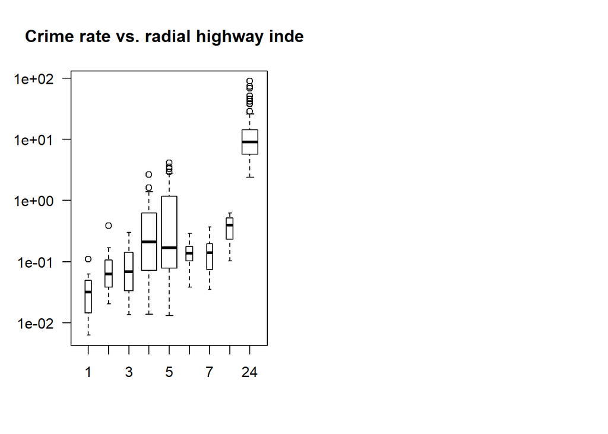

```r
mfrow(1, 2)
# Create a variable-width boxplot with log y-axis & horizontal labels
boxplot(crim ~ rad, data = Boston,
        log = "y",
        las = 1,
        varwidth = TRUE)

# Add a title
title(main = "Crime rate vs. radial highway index")

#he wider boxplots for rad = 4, 5, and 24 how much larger these subsets are than the others.
```

### Using the mosaicplot() function

A mosaic plot may be viewed as a scatterplot between categorical variables and it is supported in R with the mosaicplot() function.

As this example shows, in addition to categorical variables, this plot can also be useful in understanding the relationship between numerical variables, either integer- or real-valued, that take only a few distinct values.

More specifically, this exercise asks you to construct a mosaic plot showing the relationship between the numerical carb and cyl variables from the mtcars data frame, variables that exhibit 6 and 3 unique values, respectively.

Apply the mosaicplot() function with the formula interface to see how the levels of the carb variable vary with the levels of the cyl variable from the mtcars data frame.

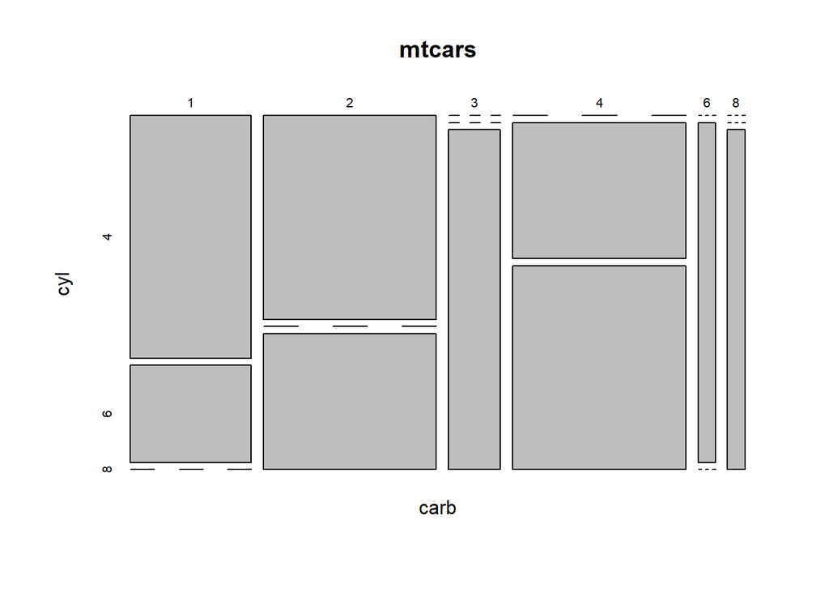

```r
# Create a mosaic plot using the formula interface
mosaicplot(carb ~ cyl, data = mtcars)
```

```r
#only 8 cyl cars have 8 barrelled carbs
```

### More Complex Variable Relations

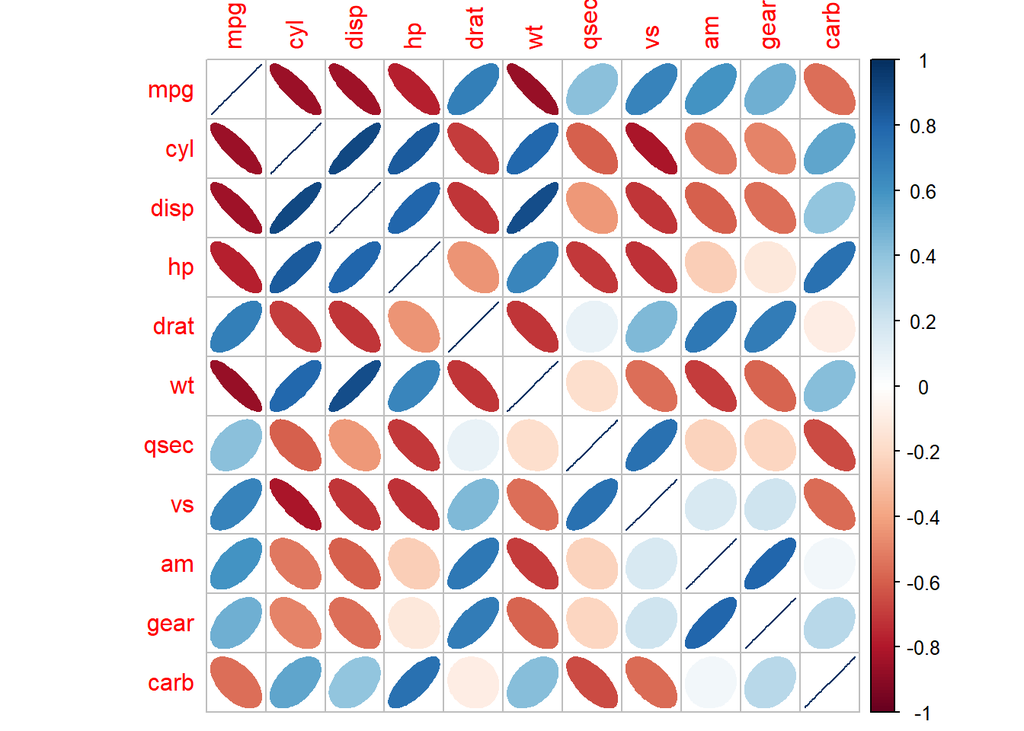

```r
mfrow(1,1)
mtCor <- cor(mtcars)
library(corrplot)
corrplot(mtCor, method = "ellipse")
```

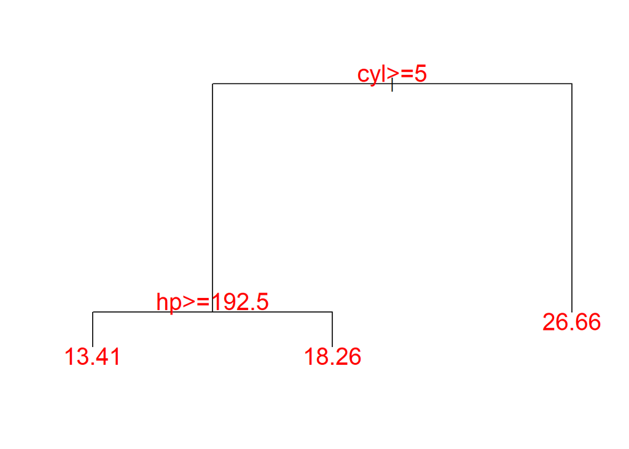

```r
library(rpart)
treemodel <- rpart(mpg ~ ., data = mtcars)
plot(treemodel)
text(treemodel, cex = 1.6, col = "red", xpd = "TRUE")
```

### Using the bagplot() function

A single box plot gives a graphical representation of the range of variation in a numerical variable, based on five numbers:

The minimum and maximum values The median (or “middle”) value Two intermediate values called the lower and upper quartiles In addition, the standard box plot computes a nominal data range from three of these numbers and flags points falling outside this range as outliers, representing them as distinct points.

The bag plot extends this representation to two numerical variables, showing their relationship, both within two-dimensional “bags” corresponding to the “box” in the standard boxplot, and indicating outlying points outside these limits.

Use the boxplot() function to construct side-by-side box plots for Min.Price and Max.Price from the Cars93 data frame. Load the aplpack package to make the bagplot() function available. Construct the bag plot showing the relationship between the Min.Price and Max.Price variables from the Cars93 data frame. Use the cex parameter to make the point sizes in this plot 20 percent larger than the default size. Use the abline() function to add a dashed equality reference line with intercept 0 and slope 1.

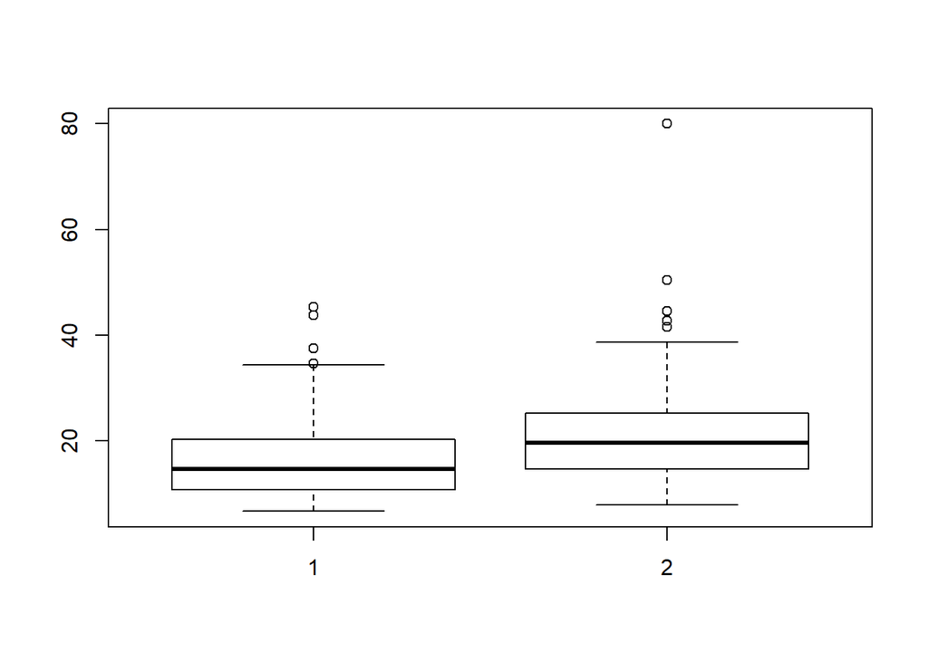

```r
# Create a side-by-side boxplot summary
boxplot(Cars93$Min.Price, Cars93$Max.Price)
```

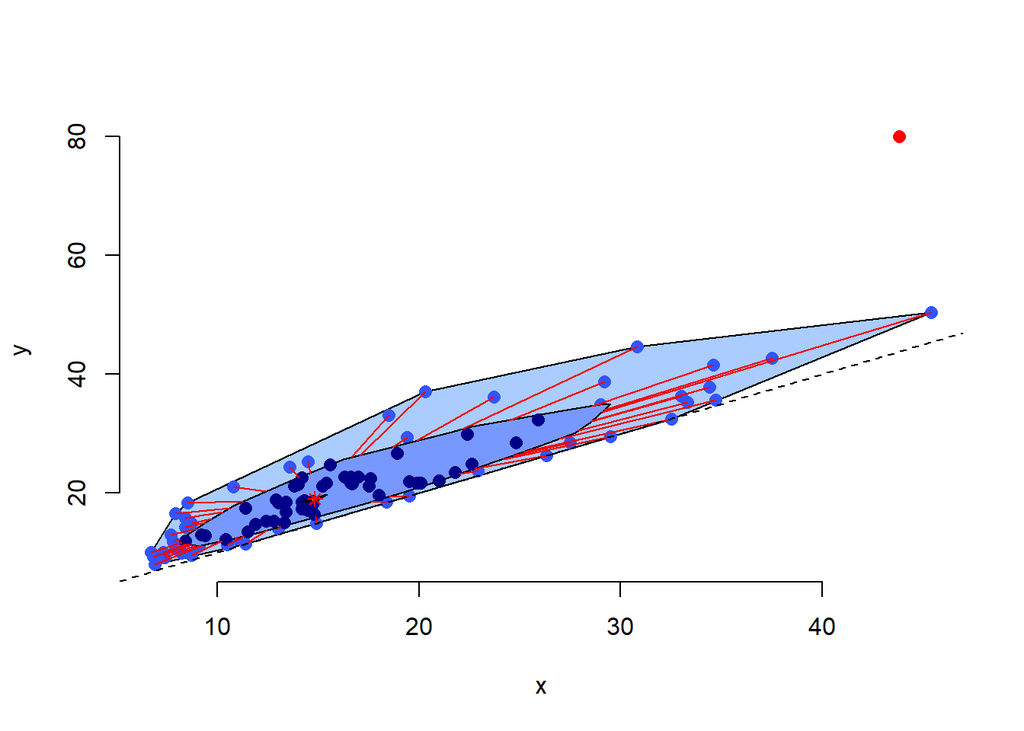

```r
# Load aplpack to make the bagplot() function available
library(aplpack)
# Create a bagplot for the same two variables
bagplot(Cars93$Min.Price, Cars93$Max.Price, cex = 1.20)

# Add an equality reference line
abline(0, 1, lty = 2)
```

```r
#notice the outlier in the upper right, with Max.Price much larger than Min.Price? It's a Mercedes-Benz 300E.
```

### Plotting correlation matrices with the corrplot() function

Correlation matrices were introduced in the video as a useful tool for obtaining a preliminary view of the relationships between multiple numerical variables.

This exercise asks you to use the corrplot() function from the corrplot package to visualize this correlation matrix for the numerical variables from the UScereal data frame in the MASS package. Recall that in this version of these plots, ellipses that are thin and elongated indicate a large correlation value between the indicated variables, while ellipses that are nearly circular indicate correlations near zero.

Create a subset of the UScereal data frame that contains only the 9 numerical (i.e., non-factor) variables. Save the result as numericalVars. Apply the cor() function to this subset to compute the correlation matrix containing the correlation coefficients between all variable pairs. Save the result as corrMat. Apply the corrplot() function to display this correlation matrix, using the “ellipse” method. Which two variables are most highly correlated with potassium? Protein and fiber

```r
# Load the corrplot library for the corrplot() function
library(corrplot)

# Extract the numerical variables from UScereal - remove non-factor columns
numericalVars <- UScereal[, sapply(UScereal, function(x) !is.factor(x))]
#OR
numvars2 <- UScereal[, sapply(UScereal, function(x) is.numeric(x))]

# Compute the correlation matrix for these variables
corrMat <- cor(numericalVars)
cor(numvars2)
```

```
##            calories   protein       fat    sodium     fibre       carbo
## calories  1.0000000 0.7060105 0.5901757 0.5286552 0.3882179  0.78872268
## protein   0.7060105 1.0000000 0.4112661 0.5727222 0.8096397  0.54709029
## fat       0.5901757 0.4112661 1.0000000 0.2595606 0.2260715  0.18285220
## sodium    0.5286552 0.5727222 0.2595606 1.0000000 0.4954831  0.42356172
## fibre     0.3882179 0.8096397 0.2260715 0.4954831 1.0000000  0.20307489
## carbo     0.7887227 0.5470903 0.1828522 0.4235617 0.2030749  1.00000000
## sugars    0.4952942 0.1848484 0.4156740 0.2112437 0.1489158 -0.04082599
## shelf     0.4263400 0.3963311 0.3256975 0.2341275 0.3578429  0.26045989
## potassium 0.4765955 0.8417540 0.3232754 0.5566426 0.9638662  0.24204848
##                sugars     shelf potassium
## calories   0.49529421 0.4263400 0.4765955
## protein    0.18484845 0.3963311 0.8417540
## fat        0.41567397 0.3256975 0.3232754
## sodium     0.21124365 0.2341275 0.5566426
## fibre      0.14891577 0.3578429 0.9638662
## carbo     -0.04082599 0.2604599 0.2420485
## sugars     1.00000000 0.2900511 0.2718335
## shelf      0.29005112 1.0000000 0.4262529
## potassium  0.27183347 0.4262529 1.0000000
```

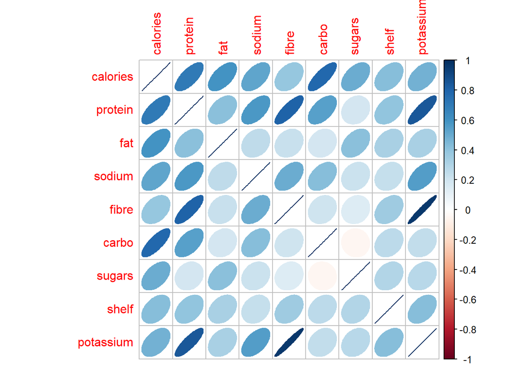

```r
# Generate the correlation ellipse plot
corrplot(corrMat, method = "ellipse")
```

### Building and plotting rpart() models

It was noted in the video that decision trees represent a popular form of predictive model because they are easy to visualize and explain. It was also noted that the rpart package is probably the most popular of several R packages that can be used to build and visualize these models.

This exercise asks you to, first, build a decision tree model using the rpart() function from this package, and then display the resulting model structure using the generic functions plot() and text().

Load the rpart package to make the rpart() modeling function and the associated methods for generic functions like plot() available. Use the rpart() function to fit a decision tree model tree_model that predicts medv in the Boston data frame from all of the other variables in this data frame. Apply the plot() function to tree_model to obtain an unlabelled plot of the structure of this decision tree model. Apply the text() function to tree_model to label this plot. To make the labels easier to read, use the cex parameter to reduce the text to 70% of the default size.

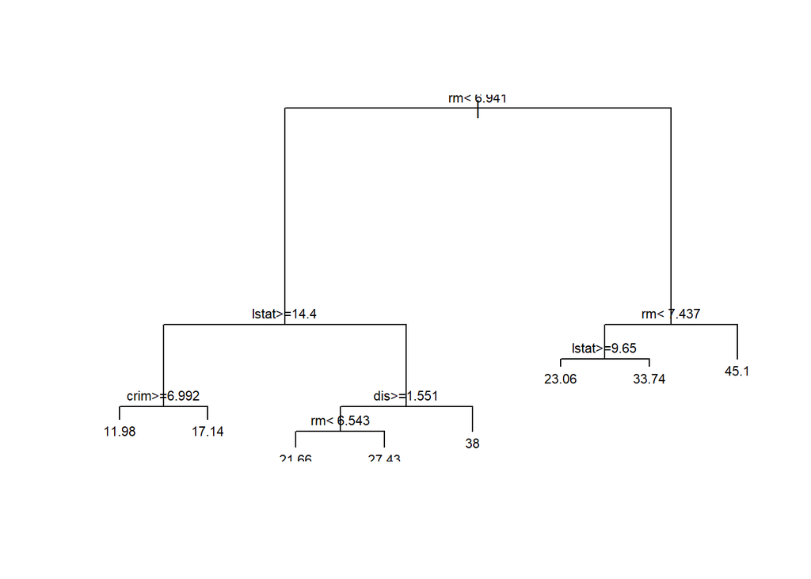

```r
# Load the rpart library
library(rpart)

# Fit an rpart model to predict medv from all other Boston variables
tree_model <- rpart(medv ~ ., data = Boston)

# Plot the structure of this decision tree model
plot(tree_model)

# Add labels to this plot
text(tree_model, cex = 0.7)
```

## Adding Details to Plots

### The plot function and its options

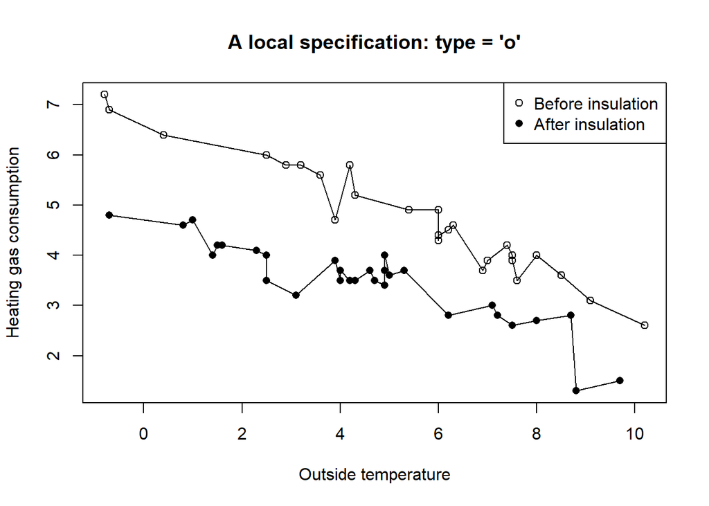

```r
rm(list = ls())
mfrow <- function(rows, cols){
        par(mfrow = c(rows, cols))
}
library(MASS)
indexA <- which(whiteside$Insul == "After")
indexB <- which(whiteside$Insul == "Before")
x <- whiteside$Temp
y <- whiteside$Gas
plot(x[indexA], y[indexA],
     type = "o",
     pch = 16,
     xlim = range(x),
     ylim = range(y),
     xlab = "Outside temperature",
     ylab = "Heating gas consumption")
lines(x[indexB], y[indexB],
      type = "o",
      pch = 1)
legend("topright", pch = c(1, 16),
       legend = c("Before insulation",
                  "After insulation"))
title("A local specification: type = 'o'")
```

```r
#type = "n" allows the creation of a plot without details which are added later
```

### Introduction to the par() function

You already saw how the mfrow parameter to the par() function could be used to plot multiple graphs in one pane. The par() function also allows you to set many other graphics parameters, whose values will remain in effect until they are reset by a subsequent par() call.

Specifically, a call to the par() function with no parameters specified will return a list whose element names each specify a graphics parameter and whose element values specify the corresponding default values of these parameters. These parameters may be set by a call in the form par(name = value) where name is the name of the parameter to be set and value is the value to be assigned to this parameter.

The purpose of this exercise is to give an idea of what these graphics parameters are. In the subsequent exercises we’ll show how some of these parameters can be used to enhance plot results.

Capture the return from the par() function as the character vector plot_pars. Show the names of these graphics parameters by calling names() on plot_pars. Show the number of parameters in this list by calling length().

```r
par()
```

[output not shown]

[output cut: 160 more lines]

[output not shown]

```r
# Assign the return value from the par() function to plot_pars
plot_pars <- par()

# Display the names of the par() function's list elements
names(plot_pars)
```

```
##  [1] "xlog"      "ylog"      "adj"       "ann"       "ask"
##  [6] "bg"        "bty"       "cex"       "cex.axis"  "cex.lab"
## [11] "cex.main"  "cex.sub"   "cin"       "col"       "col.axis"
## [16] "col.lab"   "col.main"  "col.sub"   "cra"       "crt"
## [21] "csi"       "cxy"       "din"       "err"       "family"
## [26] "fg"        "fig"       "fin"       "font"      "font.axis"
## [31] "font.lab"  "font.main" "font.sub"  "lab"       "las"
## [36] "lend"      "lheight"   "ljoin"     "lmitre"    "lty"
## [41] "lwd"       "mai"       "mar"       "mex"       "mfcol"
## [46] "mfg"       "mfrow"     "mgp"       "mkh"       "new"
## [51] "oma"       "omd"       "omi"       "page"      "pch"
## [56] "pin"       "plt"       "ps"        "pty"       "smo"
## [61] "srt"       "tck"       "tcl"       "usr"       "xaxp"
## [66] "xaxs"      "xaxt"      "xpd"       "yaxp"      "yaxs"
## [71] "yaxt"      "ylbias"
```

```r
# Display the number of par() function list elements
length(plot_pars)
```

```
## [1] 72
```

### Exploring the type option

A more detailed discussion of using the mfrow parameter is given in Chapter 4 of this course. For now, note that to specify a plot array with three rows and one column, the command would be par(mfrow = c(3, 1)).

The following exercise also introduces the type parameter for the plot() command, which specifies how the plot is drawn. The specific type values used here are:

“p” for “points” “l” for “lines” “o” for “overlaid” (i.e., lines overlaid with points) “s” for “steps”

Use the par() function to set the mfrow parameter for a two-by-two plot array. Generate a plot of brain weights from the Animals2 data frame, with observations plotted as points and the title “points” by calling the title() function. Repeat, with observations plotted as lines and the title “lines”. Repeat, with observations plotted as overlaid points and lines and the title “overlaid”. Repeat, with observations plotted as steps and the title “steps”.

```r
library(MASS)
library(tidyverse)
```

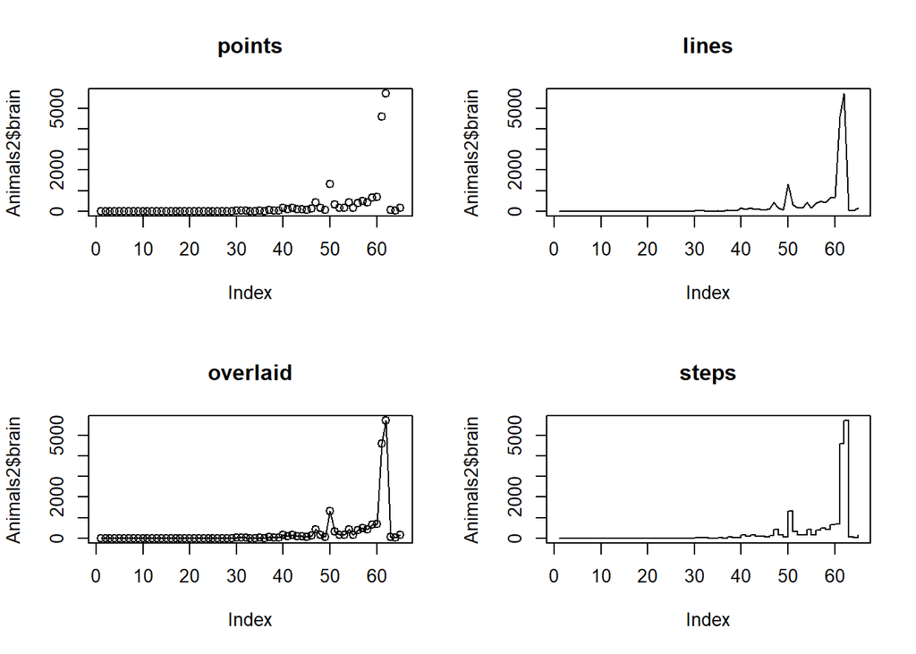

```r
#not in exercise - create Animals2

Animals2 <- local({D <- rbind(Animals, mammals); unique(D[order(D$body,D$brain),])})

# Set up a 2-by-2 plot array
par(mfrow = c(2, 2))

# Plot the Animals2 brain weight data as points
plot(Animals2$brain,
     type = "p")

# Add the title
title("points")

# Plot the brain weights with lines
plot(Animals2$brain,
     type = "l")

# Add the title
title("lines")

# Plot the brain weights as lines overlaid with points
plot(Animals2$brain,
     type = "o")

# Add the title
title("overlaid")

# Plot the brain weights as steps
plot(Animals2$brain,
     type = "s")

# Add the title
title("steps")
```

### The surprising utility of the type “n” option

The type = “n” option was discussed in the video and this exercise provides a simple example. This option is especially useful is when we are plotting data from multiple sources on a common set of axes. In such cases, we can compute ranges for the x- and y-axes so that all data points will appear on the plot, and then add the data with subsequent calls to points() or lines() as appropriate.

This exercise asks you to generate a plot that compares mileage vs. horsepower data from two different sources: the mtcars data frame in the datasets package and the Cars93 data frame in the MASS package. To distinguish the different results from these data sources, the graphics parameter pch is used to specify point shapes. See ?points for a comprehensive list of some pch values and their corresponding point shapes.

Compute max_hp as the maximum of Horsepower from the Cars93 data frame and hp from the mtcars data frame. Compute max_mpg as the maximum of MPG.city from the Cars93 data frame, MPG.highway from this data frame, and mpg from the mtcars data frame. Using the type = “n” option, set up a plot with an x-axis that runs from zero to max_hp and a y-axis that runs from zero to max_mpg, with labels Horsepower and Miles per gallon. Using the points() function, add mpg vs. hp from the mtcars data frame to the plot as open circles (pch = 1). Using the points() function, add MPG.city vs. Horsepower to the plot as solid squares (refer to the plot of pch values). Using the points() function, add MPG.highway vs. Horsepower to the plot as open triangles pointing upwards (refer to the plot of pch values).

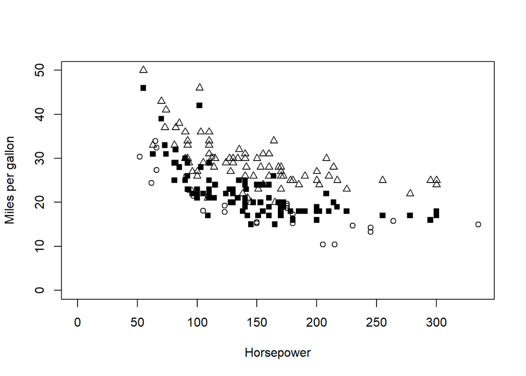

```r
mfrow(1,1)
# Compute max_hp
max_hp <- max(Cars93$Horsepower, mtcars$hp)

# Compute max_mpg
max_mpg <- max(Cars93$MPG.city, Cars93$MPG.highway, mtcars$mpg)

# Create plot with type = "n"
plot(max_hp, max_mpg,
     type = "n", xlim = c(0, max_hp),
     ylim = c(0, max_mpg), xlab = "Horsepower",
     ylab = "Miles per gallon")

# Add open circles to plot
points(mtcars$hp, mtcars$mpg, pch = 1)

# Add solid squares to plot
points(Cars93$Horsepower, Cars93$MPG.city, pch = 15)

# Add open triangles to plot
points(Cars93$Horsepower, Cars93$MPG.highway, pch = 2)
```